# Лекция 16. Гетерогенные эффекты и causal forests

Блок 4. Механизмы и гетерогенность

Карен Аванесян

Каузальный анализ в R на данных RLMS-HSE

# Зачем

## Один эффект — для кого?

- Весь курс мы оценивали **средние** эффекты: ATE, ATT, LATE. Но политика редко «для всех»: кому дать стипендию, кого отправить на переобучение, где открыть ясли
- Взаимодействия в регрессии (лекция 4) — ручной перебор: пол × диплом, возраст × диплом… С 12 ковариатами комбинаций тысячи, и мы заранее не знаем, какие важны
- **Causal forest** (Athey, Wager): случайный лес, который растёт не для предсказания $Y$, а для поиска подгрупп с **разным эффектом**

Машинное обучение здесь не заменяет дизайн: допущение то же — условная независимость при данных $X$ (блок 1). Лес лишь честно и гибко оценивает, как эффект меняется с $X$.

## Пример занятия

27 413 наблюдений: занятые 25–60 лет, 2015–2019

≈ 0.3 средняя отдача от диплома, лог (лекция 4)

11 признаков в $X$

вопрос

### Для кого диплом окупается больше?

$W$ = высшее образование, $Y$ = log зарплаты. Одинакова ли отдача для женщин и мужчин, молодых и старых, города и села?

помним

### Это CATE при допущении

$X$ исчерпывает отбор в вуз. Способности остаются за кадром, как и в лекции 4.

## План занятия

1. CATE и почему его трудно оценить
2. Как устроен causal forest: честность, ортогонализация
3. Оценка, калибровка, важность переменных; как читать вывод `grf` и писать результат
4. Кому помогает больше: BLP, RATE, разрезы
5. От эффекта к правилу: две половины, RATE, `policytree`
6. Чего не стоит ждать от леса

# Идея

## CATE и его проблема

$$\tau(x) = E[Y(1) - Y(0) \mid X = x]$$

- Для каждого $x$ нужны и обработанные, и необработанные — локально. Чем больше $X$, тем меньше соседей
- Наивный путь: обучить две модели $\hat\mu_1(x)$, $\hat\mu_0(x)$ и вычесть. Ошибки каждой модели не связаны с эффектом, разность шумит сильнее, чем сам эффект
- Нужны методы, которые **целятся в разность**, а не в уровни

## Как устроен causal forest

**Ортогонализация** (R-learner): $\tilde Y = Y - \hat m(X)$, $\tilde W = W - \hat e(X)$. Остаётся «чистая» вариация воздействия — как FWL (лекция 4) и DR (лекция 6)

**Разбиение**: дерево делит $X$ так, чтобы **эффект** $\tilde Y$ на $\tilde W$ максимально различался между листьями

**Честность**: половина выборки строит разбиения, другая оценивает эффект в листьях. Иначе лес «находит» гетерогенность в шуме

**Усреднение**: тысячи деревьев; $\hat\tau(x)$ — взвешенная локальная регрессия с весами «соседства»

Результат: оценки $\hat\tau(x)$ с доверительными интервалами и асимптотикой (Wager & Athey 2018).

## Что делать с $\hat\tau(x)$

| Вопрос | Функция `grf` |
| --- | --- |
| Средний эффект (AIPW, как в лекции 6) | `average_treatment_effect()` |
| Есть ли гетерогенность вообще? | `test_calibration()` |
| Как эффект линейно зависит от $X$ | `best_linear_projection()` |
| Выгодно ли таргетировать по $\hat\tau$? | `rank_average_treatment_effect()` |
| По каким $X$ лес делит | `variable_importance()` |
| Кого выбрать, если воздействие стоит денег | `policytree::policy_tree()` |

Не стройте выводы по разрезам $\hat\tau(x)$ «на глаз»: доверяйте тестам (калибровка, RATE, BLP), которые используют честное разбиение.

# Код

## Обучаем лес

```r
cf <- causal_forest(X, Y, W, num.trees = 2000, clusters = d$idind, seed = 1)
average_treatment_effect(cf)                              # AIPW-оценка ATE с ортогонализацией
```

```
estimate  std.err
  0.2759   0.0123
```

- `clusters = idind`: один человек встречается в нескольких годах; деревья и ошибки учитывают это
- 0.27 — близко к регрессии с теми же контролями (лекция 4): в среднем лес не открыл ничего нового. Интерес — в разбросе

## Как читать вывод `average_treatment_effect()`

- Вывод R
- С пояснениями

```r
rbind(all     = average_treatment_effect(cf),                             # ATE
      treated = average_treatment_effect(cf, target.sample = "treated"),  # ATT
      overlap = average_treatment_effect(cf, target.sample = "overlap"))  # веса e(x)(1 - e(x))
```

```
        estimate std.err
all        0.276  0.0123
treated    0.270  0.0133
overlap    0.276  0.0124
```

```r
summary(cf$W.hat)                                                         # оценённые пропенсити
```

```
   Min. 1st Qu.  Median    Mean 3rd Qu.    Max.
  0.107   0.260   0.371   0.384   0.483   0.859
```

1 · `estimate`

AIPW-оценка в единицах исхода: 0.276 лога ≈ **+32 %** к зарплате от диплома

2 · `std.err`

Из дважды робастных скоров с учётом `clusters = idind`. 95 % ДИ: [0.252; 0.3]

3 · `target.sample`

`all` — ATE, `treated` — ATT, `control` — ATC, `overlap` — эффект там, где есть и те и другие. Каждый — свой эстиманд

4 · `W.hat`

Пропенсити диплома, оценённые лесом вне выборки дерева: от 0.11 до 0.86. Перекрытие хорошее — поэтому три оценки близки

5 · что внутри

Ортогонализация `Y.hat`, `W.hat` и AIPW, как в лекции 6. Расхождение с DR-оценкой лекции 6 — повод искать ошибку

6 · сигналы беды

Предупреждение grf о пропенсити у 0 или 1; `all` и `overlap` сильно расходятся; s.e. «взрывается»

## Есть ли гетерогенность: `test_calibration()`

- Вывод R
- С пояснениями

```r
test_calibration(cf)
```

```
Best linear fit using forest predictions (on held-out data)
as well as the mean forest prediction as regressors, along
with one-sided heteroskedasticity-robust (HC3) SEs:

                               Estimate Std. Error t value               Pr(>t)
mean.forest.prediction           0.9990     0.0443   22.54 < 0.0000000000000002 ***
differential.forest.prediction   0.9038     0.1241    7.28     0.00000000000017 ***
---
Signif. codes:  0 '***' 0.001 '**' 0.01 '*' 0.05 '.' 0.1 ' ' 1
```

1 · шапка

Регрессия остатка исхода на прогнозы леса **вне выборки** (out-of-bag). Ошибки HC3 с учётом кластеров леса — заголовок о них молчит

2 · `mean.forest.prediction`

0.999 ≈ 1: средний эффект лес предсказывает верно

3 · `differential…`

0.9: насколько разброс $\hat\tau(x)$ настоящий. 1 — откалиброван, < 1 — лес преувеличивает разброс, > 1 — недооценивает

4 · `Pr(>t)`

p-value **односторонние**: H0 «коэффициент ≤ 0». Значимый `differential` — омнибус-тест: гетерогенность есть

5 · чего не скажет

Где и по каким $X$ эффект разный. Для этого — `best_linear_projection()` и RATE на отложенной половине

6 · сигналы беды

`differential` ≈ 0, отрицателен или незначим — разрезы $\hat\tau$ будут шумом; `mean` далеко от 1

## Распределение CATE

- Результат
- Код

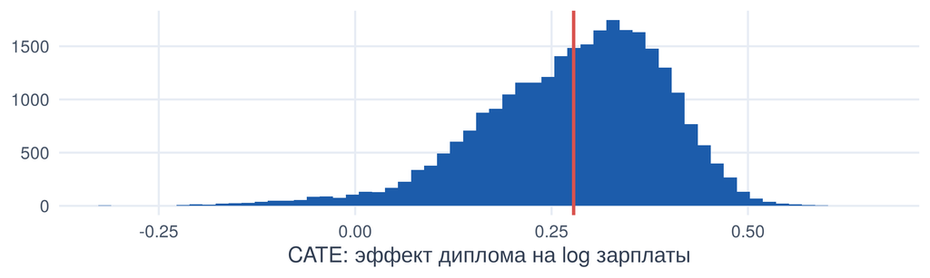

```r
d$tau <- predict(cf)$predictions
ggplot(d, aes(tau)) + geom_histogram(bins = 60, fill = pal["indigo"]) +
  geom_vline(xintercept = mean(d$tau), colour = pal["coral"], linewidth = 1.1) +
  labs(x = "CATE: эффект диплома на log зарплаты", y = NULL)
```

От −0.1 до 0.6 — разброс не шум: калибровка это подтвердила. Но у отдельных $\hat\tau(x_i)$ широкие интервалы — смотрим на группы, а не на людей.

## По каким переменным делит лес

```r
tibble(переменная = colnames(X), важность = round(variable_importance(cf)[, 1], 3)) |>
  arrange(-важность) |> head(6)
```

| переменная | важность |
| --- | --- |
| age | 0.390 |
| experience | 0.349 |
| site_code | 0.131 |
| n_children | 0.043 |
| female | 0.035 |
| state_owned | 0.016 |

Возраст и опыт — главные источники гетерогенности; площадка — третья. Важность говорит, **где лес искал**, а не что является причиной различий.

## Разрезы: возраст, пол, поселение

- Результат
- Код

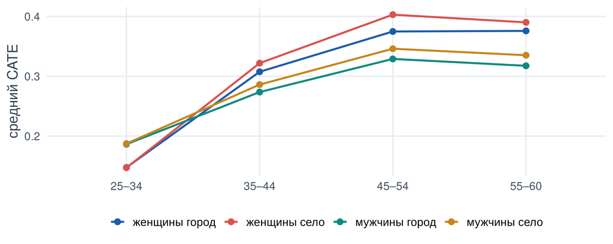

```r
d |> mutate(возраст = cut(age, c(24, 34, 44, 54, 60),
                          labels = c("25–34", "35–44", "45–54", "55–60")),
            группа = paste(ifelse(female == 1, "женщины", "мужчины"),
                           ifelse(urban == 1, "город", "село"))) |>
  group_by(возраст, группа) |> summarise(cate = mean(tau), .groups = "drop") |>
  ggplot(aes(возраст, cate, colour = группа, group = группа)) +
  geom_line(linewidth = 1) + geom_point(size = 2.5) +
  labs(x = NULL, y = "средний CATE", colour = NULL)
```

## Как читать вывод `best_linear_projection()`

- Вывод R
- С пояснениями

```r
best_linear_projection(cf, X[, c("female", "age", "urban", "state_owned")])
```

```
Best linear projection of the conditional average treatment effect.
Confidence intervals are cluster- and heteroskedasticity-robust (HC3):

            Estimate Std. Error t value      Pr(>|t|)
(Intercept) -0.07981    0.05839   -1.37          0.17
female       0.02522    0.02548    0.99          0.32
age          0.00833    0.00132    6.31 0.00000000028 ***
urban       -0.02122    0.02964   -0.72          0.47
state_owned  0.03754    0.02478    1.52          0.13
---
Signif. codes:  0 '***' 0.001 '**' 0.01 '*' 0.05 '.' 0.1 ' ' 1
```

1 · что это

Линейная аппроксимация CATE по выбранным $A$: $\tau(x) \approx \beta_0 + A\beta$, на дважды робастных скорах; ошибки HC3 с кластерами

2 · `(Intercept)`

Эффект при всех $A = 0$: мужчина нулевого возраста из села — экстраполяция, не читаем

3 · `age`

+0.0083 к эффекту диплома за год: у 55-летних отдача на 0.25 лога выше, чем у 25-летних

4 · остальные

Пол, город, госсектор при учёте возраста незначимы (p = 0.32, 0.47, 0.13)

5 · как понимать

Описание, у кого эффект больше, а не причина. Коррелированные $A$ делят гетерогенность: добавьте опыт — и «эффект возраста» поделится с ним

6 · сигналы беды

$A$ выбраны, глядя на разрезы $\hat\tau$ (двойное использование данных); много $A$ при малом N; коэффициенты читают как механизмы

## Как писать результат

шаблон

«При допущении, что 11 наблюдаемых характеристик исчерпывают отбор в вуз, causal forest (2 000 деревьев, кластеры по респонденту) оценивает средний эффект высшего образования в **0.276 лога** зарплаты (s.e. 0.012), т. е. около +32 %. Тест калибровки подтверждает гетерогенность (коэффициент при дифференциальном прогнозе 0.9, одностороннее p < 0.001). Эффект растёт с возрастом: +0.0083 лога за год (s.e. 0.0013) в линейной проекции CATE; пол, тип поселения и госсектор при учёте возраста гетерогенности не добавляют.»

- Обязательно: допущение условной независимости, эстиманд (ATE / ATT), кластеры; гетерогенность — через калибровку, BLP или RATE, а не через гистограмму $\hat\tau$
- Не писать «возраст повышает отдачу от диплома»: BLP описывает, **у кого** эффект больше (и, возможно, у кого больше смещение отбора)

## Почему эффект растёт с возрастом

механизм

### Карьерный профиль

Диплом открывает должности, где зарплата растёт с опытом; без диплома профиль плоский.

SUTVA, лекция 1

### Когорты

55-летние учились в советских вузах, 25-летние — в массовом высшем 2010-х; «диплом» — не одно и то же воздействие.

угроза

### Отбор

Среди старших дипломированные — более отобранная группа; при неизмеренных способностях «гетерогенность» может быть гетерогенностью **смещения**.

Лес показывает, **где** эффект отличается. **Почему** — вопрос к теории и к дизайну, не к алгоритму.

## Честная оценка правил: две половины

Выгодно ли таргетировать по $\hat\tau$? Правило нельзя проверять на данных, где оно построено (даже с OOB). Делим **людей** пополам: на одной половине строим, на другой — оцениваем.

```r
ids <- unique(d$idind); set.seed(1); tr <- d$idind %in% sample(ids, length(ids) / 2)
cf_tr <- causal_forest(X[tr, ], Y[tr], W[tr], num.trees = 1000,
                       clusters = d$idind[tr], seed = 1)
cf_ev <- causal_forest(X[!tr, ], Y[!tr], W[!tr], num.trees = 1000,
                       clusters = d$idind[!tr], seed = 1)
prio <- predict(cf_tr, X[!tr, ])$predictions         # приоритет из "обучающего" леса
rate <- rank_average_treatment_effect(cf_ev, prio)   # оценка на "проверочном"
rate
```

```
 estimate std.err             target
   0.0374  0.0181 priorities | AUTOC
```

AUTOC ≈ 0.04, значимо: если бы «дипломы» давали по убыванию $\hat\tau$, средний эффект у получивших был бы выше, чем при случайной раздаче.

## TOC-кривая

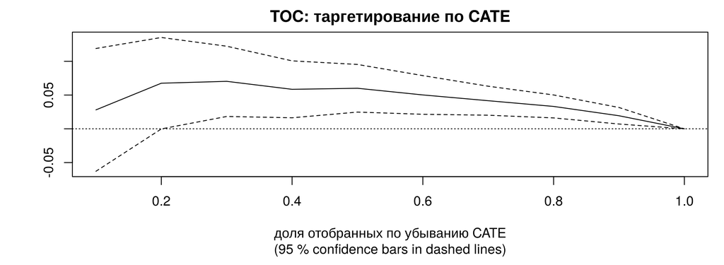

```r
par(mar = c(5.5, 4.5, 2, 1))
plot(rate, main = "TOC: таргетирование по CATE", xlab = "доля отобранных по убыванию CATE")
```

Кривая: средний эффект среди первых $q\%$ по приоритету минус общий ATE. Площадь под ней — AUTOC.

## А если правило проще?

```r
rate_age <- rank_average_treatment_effect(cf_ev, X[!tr, "age"])
rate_age
```

```
 estimate std.err             target
   0.0437  0.0176 priorities | AUTOC
```

- Приоритет «просто по возрасту» даёт такой же AUTOC, как лес: вся гетерогенность, которую стоит использовать, — возрастная
- На одном лесе (`rank_average_treatment_effect(cf, d$tau)`) AUTOC вышел бы вдвое больше — это winner’s curse, а не польза

## От эффекта к правилу: `policytree`

Пусть воздействие стоит $c = 0.3$ лога (столько «съедают» годы учёбы). Давать его стоит там, где $\tau(x) > c$. Дерево глубины 2 по дважды робастным оценкам, со штрафом за стоимость:

```r
dr_tr <- double_robust_scores(cf_tr)          # столбцы: Y(0), Y(1) для каждого наблюдения
dr_tr[, 2] <- dr_tr[, 2] - 0.3                # воздействие стоит 0.3
pt_X <- X[, c("age", "female", "urban", "state_owned")]
tree <- policy_tree(pt_X[tr, ], dr_tr, depth = 2)
tree
```

```
policy_tree object
Tree depth:  2
Actions:  1: control 2: treated
Variable splits:
(1) split_variable: urban  split_value: 0
  (2) split_variable: age  split_value: 38
    (4) * action: 1
    (5) * action: 2
  (3) split_variable: age  split_value: 36
    (6) * action: 1
    (7) * action: 2
```

## Проверяем правило на второй половине

```r
dr_ev <- double_robust_scores(cf_ev); dr_ev[, 2] <- dr_ev[, 2] - 0.3
a <- predict(tree, pt_X[!tr, ])                      # 1 = не давать, 2 = давать
tibble(правило = c("никому", "всем", "по дереву"),
       доля = c(0, 1, mean(a == 2)),
       выигрыш = c(0, mean(dr_ev[, 2] - dr_ev[, 1]),
                   mean(dr_ev[cbind(seq_along(a), a)] - dr_ev[, 1]))) |>
  mutate(across(-правило, \(x) round(x, 3)))
```

| правило | доля | выигрыш |
| --- | --- | --- |
| никому | 0.0 | 0.000 |
| всем | 1.0 | -0.023 |
| по дереву | 0.6 | 0.015 |

- «Всем» при цене 0.3 даёт убыток: средний эффект ниже цены. Дерево — делить по возрасту (≈ 36–38 лет) — даёт выигрыш
- Выигрыш считаем на половине, которую дерево **не видело**: это честная оценка, в отличие от «выигрыша» на обучающей половине

## Чтение правила

- Правило «давать старшим» в терминах политики странно: стипендии дают молодым. Это сигнал, что мы оценили **гетерогенность ассоциации при данных контролях**, а не эффект стипендии
- Для реального правила нужен дизайн, где диплом «как случайный»: `instrumental_forest` с инструментом (лекция 12) или эксперимент
- `policytree` полезен там, где воздействие действительно назначается: программы занятости, адресная помощь, напоминания

# Как ошибаются

## Шесть ошибок с causal forests

1. Лес вместо дизайна: «нейросеть нашла эффект» при тех же ненаблюдаемых конфаундерах
2. Гетерогенность по разрезам $\hat\tau(x)$ без теста калибровки и RATE
3. Интерпретация важности переменных как причин гетерогенности
4. Нет кластеризации по человеку в панели — интервалы занижены
5. Таргетирование по $\hat\tau$ без учёта того, что эффект на отложенной выборке меньше (winner’s curse)
6. Правило `policytree` на наблюдательных данных как готовая политика

## Чек-лист

- Условная независимость аргументирована так же, как для регрессии и мэтчинга
- `average_treatment_effect` совпадает с DR-оценкой из лекции 6 (иначе — почему?)
- `test_calibration` и RATE — до любых разрезов
- Кластеры по единице наблюдения
- Гетерогенность объяснена теорией, а не только найдена
- Для правил — честная оценка на отложенной выборке

# Мини-задача

## Задание к следующему занятию

1. Обучите causal forest для эффекта **допобучения** (`training_12m`) на зарплату (лекция 5), с `log_wage_prev` в $X$. Есть ли гетерогенность? Кому обучение помогает больше?
2. Постройте RATE с приоритетом «по прошлой зарплате» вместо $\hat\tau$. Что лучше таргетирует?
3. `instrumental_forest`: оцените гетерогенность LATE из нечёткой RD (лекция 12): инструмент «возраст ≥ 55», воздействие — пенсия, исход — занятость. Где эффект пенсии на занятость сильнее?
4. Объясните в абзаце, почему лес не решил проблему способностей из лекции 1

# Литература

## Что прочитать

- Wager S., Athey S. (2018). Estimation and Inference of Heterogeneous Treatment Effects using Random Forests. *JASA*
- Athey S., Tibshirani J., Wager S. (2019). Generalized Random Forests. *Annals of Statistics*
- Yadlowsky S. et al. (2021). Evaluating Treatment Prioritization Rules via Rank-Weighted Average Treatment Effects — RATE
- Athey S., Wager S. (2021). Policy Learning with Observational Data. *Econometrica* — `policytree`
- Документация [`grf`](https://grf-labs.github.io/grf/): виньетки «Estimating treatment effects» и «Qini curves»
- Huntington-Klein N. *The Effect*, гл. 21 «Machine Learning»

Каузальный анализ в R · RLMS-HSE · К. Аванесян

← К программе курса